# Communicate Data Finding : Prosper Loan Data

## by Edwin Kihara

# What the Project will test

- Introduction of the topic and dataset
- Dataset Investigation and preliminary wrangling
- Further Data Wrangling
- Univariate Exploration and Analysis
- Bivariate Exploration and Analysis
- Multivariate Exploration and Analysis
- Conclusions and answers

## Dataset

> - Loan Data from Prosper: This data set contains 113,937 loans with 81 variables on each loan, including loan amount, borrower rate (or interest rate), current loan status, borrower income, and many others
> - The source data (Prosper Loan Data) was from Udacity website.

Since the dataset contains a large volume of columns, I extracted 21 columns that seemed useful for my analysis.

## Primary justification for loan applications

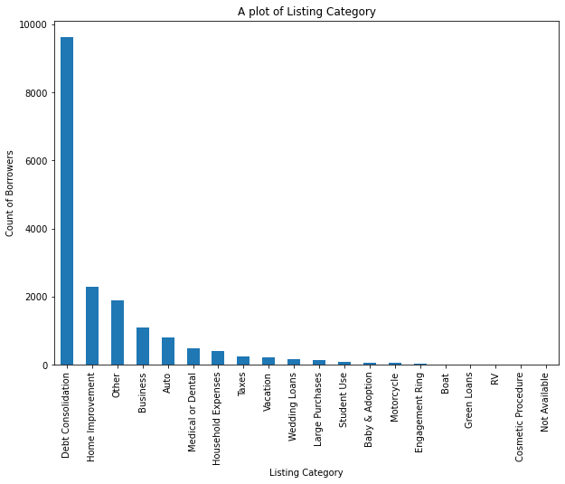

> Aside from financing their businesses and house related expenses, people appear to rely on loans to pay for their weddings, pay taxes, using the loans to fund for vaccation, child adaption, making large purchases, and student use.

## Do borrowers take on more debt than they can reasonably pay off?

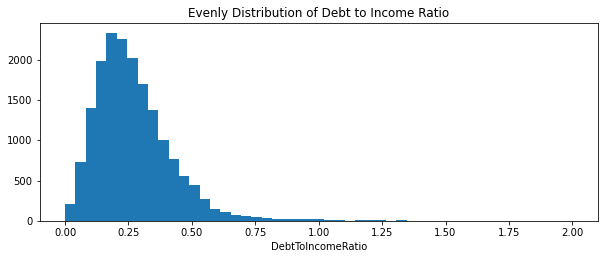

> Right-skewed distribution can be seen in the debt-to-income ratio. Most borrowers appear to choose taking out loans that are affordable. This is understandable because the majority of numbers are spread out between 0 and 1.

## The main monetary ranges of existing clients

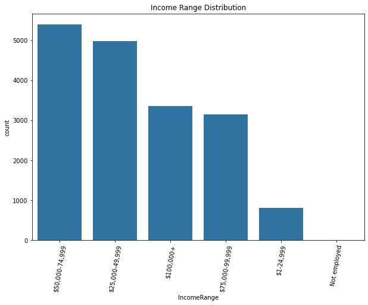

## Distribution of Loan Status

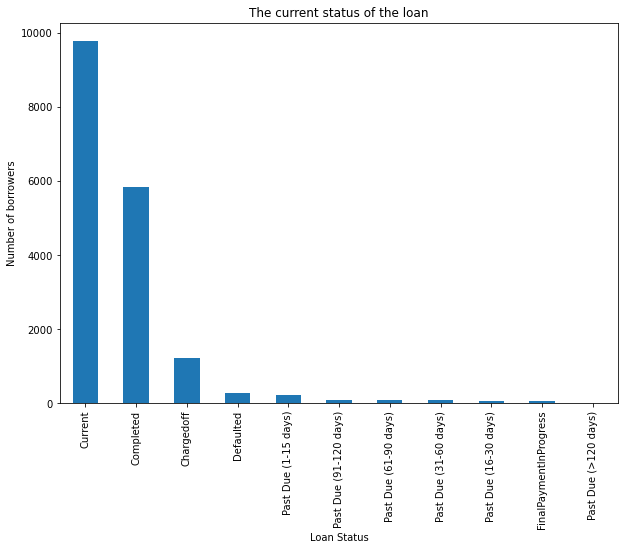

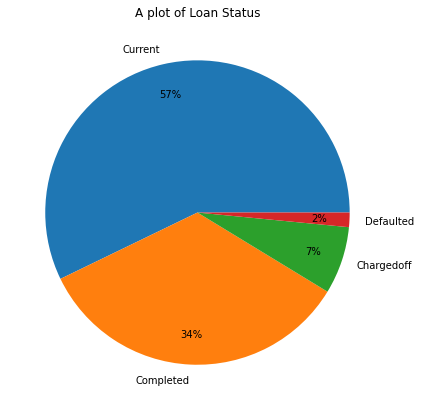

> About 57% of the information is made up primarily of Current loans. Another significant component of the listings, at 34%, is made up of Completed loans. Even though there aren't many loans that default, roughly 7% of them are charged off, suggesting losses for investors. It will be difficult to determine at this time if borrowers have been making their loan payments because the majority of the listings are current loans.

## Which occupation gets highest loan amount on an average?

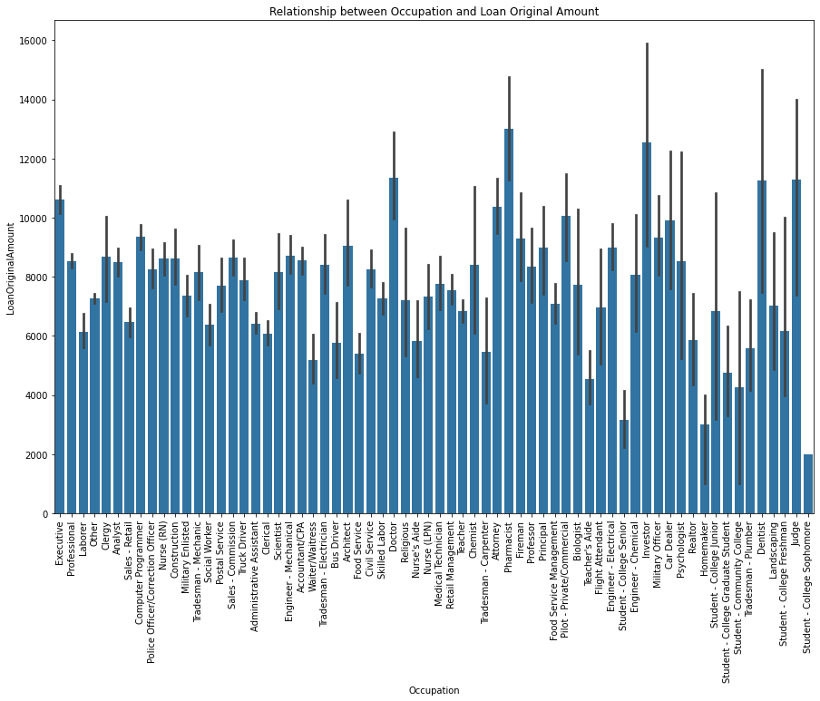

## How does loan amount differ with respect to the income range?

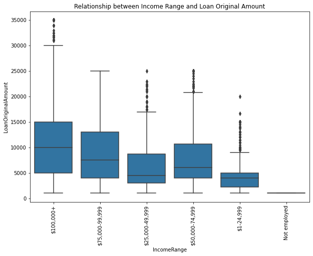

[output not shown]

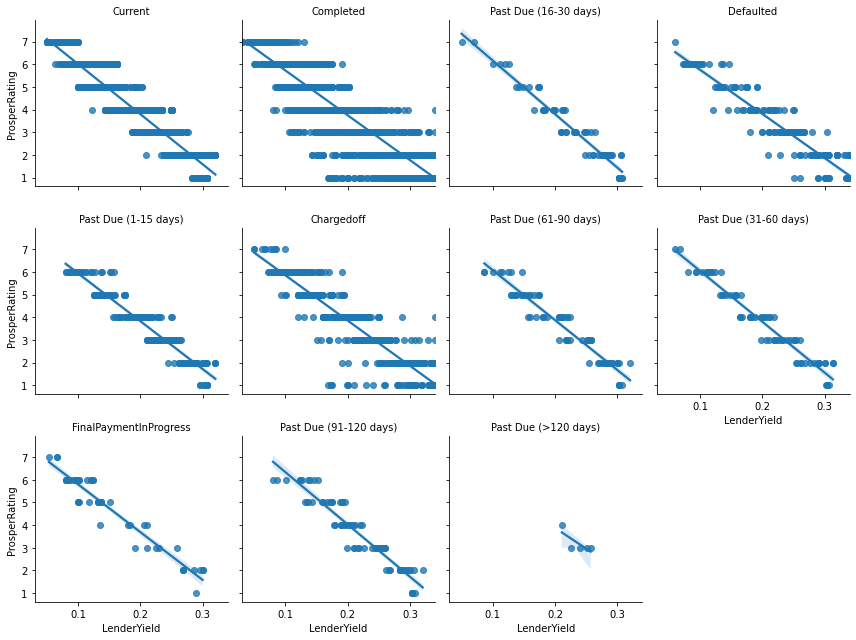